# Getting DEB parameters from the web and from allStat.mat in R

Michael Kearney

2018-08-20

### Overview

The R programming environment provides many ways to visualise and analyse DEB parameters. This ‘work-in-progress’ document shows how to bring the AmP collection into R in two ways, by ‘web-scraping’ and by working with the allStat.mat file. The latter is most powerful but the former can be useful in some situations.

### Web scraping

Obtaining data directly from the web is a useful skill and can be done in R through a variety of packages and approaches. Here we use ‘rvest’ package.

```r
library(rvest)
library(knitr)
```

Included here are three example functions that will obtain data from different pages of the AmP web site.

The first one, ‘getDEB.species’, goes to the ‘species_list’ page on the AmP site and obtains all the classification, model fit and completeness information. The correct nodes to obtain the relevant data were determined using [selectorgadget](https://selectorgadget.com/) which is a plug-in for your browser allowing you to click on different parts of a webpage and get the node names.

```r
getDEB.species <- function() {
    require(rvest)
    library(rvest)
    url <- "https://www.bio.vu.nl/thb/deb/deblab/add_my_pet/species_list.html"
    d1 <- read_html(url)

    phylum <- d1 %>% html_nodes("td:nth-child(1)") %>% html_text()
    class <- d1 %>% html_nodes("td:nth-child(2)") %>% html_text()
    order <- d1 %>% html_nodes("td:nth-child(3)") %>% html_text()
    family <- d1 %>% html_nodes("td:nth-child(4)") %>% html_text()
    species <- d1 %>% html_nodes("td:nth-child(5)") %>% html_text()
    common <- d1 %>% html_nodes("td:nth-child(6)") %>% html_text()
    type <- d1 %>% html_nodes("td:nth-child(7)") %>% html_text()
    mre <- d1 %>% html_nodes("td:nth-child(8)") %>% html_text()
    smre <- d1 %>% html_nodes("td:nth-child(9)") %>% html_text()
    complete <- d1 %>% html_nodes("td:nth-child(10)") %>% html_text()
    all.species <- as.data.frame(cbind(phylum, class, order,
        family, species, common, type, mre, smre, complete),
        stringsAsFactors = FALSE)
    all.species$species <- gsub(" ", "_", all.species$species)
    all.species$mre <- as.numeric(mre)
    all.species$smre <- as.numeric(smre)
    all.species$complete <- as.numeric(complete)
    return(all.species)
}
```

The next one, ‘getDEB.pars’ gets all the parameters from the pars page of a species of interest from the list of species obtained with ‘getDEB.species’. Due to the structure of the tables for the chemical composition parameters the code is a little less straight-forward.

```r
getDEB.pars <- function(species) {
    require(rvest)
    library(rvest)
    baseurl <- "https://www.bio.vu.nl/thb/deb/deblab/add_my_pet/entries_web/"
    d1 <- read_html(paste0(baseurl, species, "/", species, "_par.html"))
    symbol1 <- d1 %>% html_nodes("td:nth-child(1)") %>% html_text()

    value1 <- d1 %>% html_nodes("td:nth-child(2)") %>% html_text()

    units1 <- d1 %>% html_nodes("td:nth-child(3)") %>% html_text()

    description1 <- d1 %>% html_nodes("td:nth-child(4)") %>%
        html_text()

    extra1 <- d1 %>% html_nodes("td:nth-child(5)") %>% html_text()

    extra2 <- d1 %>% html_nodes("td:nth-child(6)") %>% html_text()
    end <- which(symbol1 == "T_ref")
    symbol <- symbol1[1:end]
    value <- value1[1:end]
    units <- units1[1:end]
    description <- description1[1:end]

    pars <- as.data.frame(cbind(symbol, value, units, description))
    pars$symbol <- as.character(symbol)
    pars$value <- as.numeric(value)
    pars$units <- as.character(units)
    pars$description <- as.character(description)

    chempot <- c(value1[end + 1], units1[end + 1], description1[end +
        1], extra1[1])
    dens <- c(value1[end + 2], units1[end + 2], description1[end +
        2], extra1[2])
    org.C <- c(units1[end + 3], description1[end + 3], extra1[3],
        extra2[1])
    org.H <- c(value1[end + 4], units1[end + 4], description1[end +
        4], extra1[4])
    org.O <- c(value1[end + 5], units1[end + 5], description1[end +
        5], extra1[5])
    org.N <- c(value1[end + 6], units1[end + 6], description1[end +
        6], extra1[6])
    min.C <- c(units1[end + 7], description1[end + 7], extra1[7],
        extra2[2])
    min.H <- c(value1[end + 8], units1[end + 8], description1[end +
        8], extra1[8])
    min.O <- c(value1[end + 9], units1[end + 9], description1[end +
        9], extra1[9])
    min.N <- c(value1[end + 10], units1[end + 10], description1[end +
        10], extra1[10])

    organics <- rbind(org.C, org.H, org.O, org.N)
    minerals <- rbind(min.C, min.H, min.O, min.N)
    colnames(organics) <- c("X", "V", "E", "P")
    colnames(minerals) <- c("CO2", "H2O", "O2", "N-waste")
    rownames(organics) <- c("C", "H", "O", "N")
    rownames(minerals) <- c("C", "H", "O", "N")
    class(chempot) <- "numeric"
    class(dens) <- "numeric"
    class(organics) <- "numeric"
    class(minerals) <- "numeric"

    return(list(pars = pars, chempot = chempot, dens = dens,
        organics = organics, minerals = minerals))
}
```

Finally, ‘getDEB.implied.R’ obtains all the implied properties.

```r
getDEB.implied <- function(species) {
    require(rvest)
    library(rvest)
    baseurl <- "https://www.bio.vu.nl/thb/deb/deblab/add_my_pet/entries_web/"
    d1 <- read_html(paste0(baseurl, species, "/", species, "_stat.html"))
    symbol <- d1 %>% html_nodes("td:nth-child(1)") %>% html_text()

    value <- d1 %>% html_nodes("td:nth-child(2)") %>% html_text()

    units <- d1 %>% html_nodes("td:nth-child(3)") %>% html_text()

    description <- d1 %>% html_nodes("td:nth-child(4)") %>% html_text()

    final <- as.data.frame(cbind(symbol, value, units, description))
    final$symbol <- as.character(symbol)
    final$value <- as.numeric(value)
    final$units <- as.character(units)
    final$description <- as.character(description)
    return(final)
}
```

Here are all the Squamata currently in the collection on the web, as returned by ‘allDEB.species’.

```r
allDEB.species <- getDEB.species()
head(allDEB.species)
```

|  | phylum | class | order | family | species | common | type | mre | smre | complete |
| --- | --- | --- | --- | --- | --- | --- | --- | --- | --- | --- |
| 1 | Porifera | Demospongiae | Haplosclerida | Chalinidae | Haliclona_oculata | Mermaid's glove | std | 0.022 | 0.039 | 1.9 |
| 2 | Cnidaria | Anthozoa | Pennatulacea | Pennatulidae | Ptilosarcus_gurneyi | Orange sea pen | std | 0.044 | 0.041 | 2.3 |
| 3 | Cnidaria | Cubozoa | Chirodropida | Chirodropidae | Chironex_fleckeri | Sea wasp | abj | 0.153 | 0.246 | 2.0 |
| 4 | Cnidaria | Hydrozoa | Anthomedusae | Hydridae | Hydra_viridissima | Green hydra | stf | 0.079 | 0.085 | 2.5 |
| 5 | Cnidaria | Scyphozoa | Semaeostomeae | Pelagiidae | Pelagia_noctiluca | Mauve stinger | abj | 0.245 | 0.262 | 3.0 |
| 6 | Cnidaria | Scyphozoa | Semaeostomeae | Cyaneidae | Cyanea_capillata | Lion's mane jellyfish | abj | 0.056 | 0.119 | 2.5 |

[output not shown]

```r
kable(subset(allDEB.species, order == "Squamata"))
```

|  | phylum | class | order | family | species | common | type | mre | smre | complete |
| --- | --- | --- | --- | --- | --- | --- | --- | --- | --- | --- |
| 547 | Chordata | Reptilia | Squamata | Gekkonidae | Heteronotia_binoei | Bynoe’s gecko CA6 | std | 0.142 | 0.175 | 2.8 |
| 548 | Chordata | Reptilia | Squamata | Gekkonidae | Heteronotia_binoei_3N1A | Bynoe’s gecko 3N1A | std | 0.117 | 0.146 | 2.8 |
| 549 | Chordata | Reptilia | Squamata | Gekkonidae | Heteronotia_binoei_3N1B | Bynoe’s gecko 3N1B | std | 0.130 | 0.157 | 2.8 |
| 550 | Chordata | Reptilia | Squamata | Gekkonidae | Heteronotia_binoei_EA6 | Bynoe’s gecko EA6 | std | 0.135 | 0.147 | 2.8 |
| 551 | Chordata | Reptilia | Squamata | Gekkonidae | Heteronotia_binoei_SM6 | Bynoe’s gecko SM6 | std | 0.153 | 0.180 | 2.8 |
| 552 | Chordata | Reptilia | Squamata | Scincidae | Eulamprus_quoyii | Eastern Water Skink | std | 0.146 | 0.147 | 2.5 |
| 553 | Chordata | Reptilia | Squamata | Scincidae | Tiliqua_rugosa | Sleepy Lizard | std | 0.109 | 0.118 | 2.7 |
| 554 | Chordata | Reptilia | Squamata | Scincidae | Egernia_cunninghami | Cunningham’s Skink | std | 0.232 | 0.247 | 2.5 |
| 555 | Chordata | Reptilia | Squamata | Scincidae | Egernia_striolata | Tree Skink | std | 0.204 | 0.239 | 2.5 |
| 556 | Chordata | Reptilia | Squamata | Scincidae | Liopholis_striata | Night Skink | std | 0.151 | 0.160 | 2.5 |
| 557 | Chordata | Reptilia | Squamata | Scincidae | Liopholis_inornata | Desert Skink | std | 0.122 | 0.126 | 2.5 |
| 558 | Chordata | Reptilia | Squamata | Amphisbaenidae | Amphisbaena_alba | Red worm lizard | std | 0.002 | 0.003 | 1.5 |
| 559 | Chordata | Reptilia | Squamata | Lacertidae | Lacerta_agilis | Sand lizard | std | 0.045 | 0.047 | 2.8 |
| 560 | Chordata | Reptilia | Squamata | Lacertidae | Lacerta_strigata | Caucusus Emerald Lizard | std | 0.049 | 0.053 | 2.8 |
| 561 | Chordata | Reptilia | Squamata | Lacertidae | Takydromus_hsuehshanensis | Snow Mountain grasslizard | std | 0.165 | 0.180 | 2.8 |
| 562 | Chordata | Reptilia | Squamata | Varanidae | Varanus_komodoensis | Komodo dragon | std | 0.070 | 0.073 | 2.5 |
| 563 | Chordata | Reptilia | Squamata | Anguidae | Anguis_fragilis | Slow worm | std | 0.106 | 0.100 | 2.5 |
| 564 | Chordata | Reptilia | Squamata | Chamaeleonidae | Furcifer_labordi | Labords chameleon | std | 0.109 | 0.112 | 2.5 |
| 565 | Chordata | Reptilia | Squamata | Agamidae | Ctenophorus_ornatus | Ornate dragon | std | 0.134 | 0.134 | 2.6 |
| 566 | Chordata | Reptilia | Squamata | Iguanidae | Cyclura_pinguis | Anegada ground iguana | std | 0.062 | 0.068 | 2.5 |
| 567 | Chordata | Reptilia | Squamata | Phrynosomatidae | Sceloporus_undulatus | Eastern fence lizard | std | 0.088 | 0.132 | 1.7 |
| 568 | Chordata | Reptilia | Squamata | Phrynosomatidae | Sceloporus_occidentalis | Western fence lizard | std | 0.096 | 0.095 | 2.5 |
| 569 | Chordata | Reptilia | Squamata | Phrynosomatidae | Phrynosoma_ditmarsi | Rock horned lizard | std | 0.033 | 0.060 | 2.8 |
| 570 | Chordata | Reptilia | Squamata | Phrynosomatidae | Phrynosoma_douglasii | Pygmy short-horned lizard | std | 0.014 | 0.024 | 2.5 |
| 571 | Chordata | Reptilia | Squamata | Pythonidae | Python_regius | Ball python | std | 0.246 | 0.171 | 3.8 |
| 572 | Chordata | Reptilia | Squamata | Pythonidae | Apodora_papuana | Irian python | std | 0.068 | 0.073 | 2.5 |
| 573 | Chordata | Reptilia | Squamata | Boidae | Eunectes_murinus | Green anaconda | std | 0.112 | 0.129 | 2.6 |
| 574 | Chordata | Reptilia | Squamata | Boidae | Eunectes_notaeus | Yellow anaconda | std | 0.105 | 0.100 | 2.6 |
| 575 | Chordata | Reptilia | Squamata | Boidae | Boa_constrictor | Columbian boa | std | 0.241 | 0.220 | 2.6 |
| 576 | Chordata | Reptilia | Squamata | Viperidae | Vipera_berus | Common European adder | std | 0.073 | 0.072 | 2.7 |
| 577 | Chordata | Reptilia | Squamata | Viperidae | Crotalus_horridus | Timber rattlesnake | std | 0.048 | 0.055 | 2.8 |
| 578 | Chordata | Reptilia | Squamata | Colubridae | Coronella_austriaca | Smooth snake | std | 0.090 | 0.101 | 2.5 |
| 579 | Chordata | Reptilia | Squamata | Colubridae | Natrix_natrix | Grass snake | std | 0.147 | 0.150 | 2.6 |

Now you can extract data for a particular species - the sand lizard *Lacerta agilis*. First, here are the parameters as extracted by ‘getDEB.pars’.

```r
allpars <- getDEB.pars("Lacerta_agilis")
pars <- allpars$pars
chempot <- allpars$chempot
dens <- allpars$dens
organics <- allpars$organics
minerals <- allpars$minerals

kable(pars)
```

| symbol | value | units | description |
| --- | --- | --- | --- |
| p_Am | 155.91200 | J/d.cm^2 | {p_Am}, spec assimilation flux |
| F_m | 6.50000 | l/d.cm^2 | {F_m}, max spec searching rate |
| kap_X | 0.80000 | - | digestion efficiency of food to reserve |
| kap_P | 0.10000 | - | faecation efficiency of food to faeces |
| v | 0.02887 | cm/d | energy conductance |
| kap | 0.79300 | - | allocation fraction to soma |
| kap_R | 0.95000 | - | reproduction efficiency |
| p_M | 65.73000 | J/d.cm^3 | [p_M], vol-spec somatic maint |
| p_T | 0.00000 | J/d.cm^2 | {p_T}, surf-spec somatic maint |
| k_J | 0.00200 | 1/d | maturity maint rate coefficient |
| E_G | 7832.00000 | J/cm^3 | [E_G], spec cost for structure |
| E_Hb | 390.80000 | J | maturity at birth |
| E_Hp | 18970.00000 | J | maturity at puberty |
| h_a | 0.00000 | 1/d^2 | Weibull aging acceleration |
| s_G | 0.00010 | - | Gompertz stress coefficient |
| del_M | 0.17650 | - | shape coefficient |
| f | 1.00000 | - | scaled functional response for 0-var data |
| f_Kh | 0.95120 | - | scaled functional response at Khuchni |
| f_Ko | 0.90610 | - | scaled functional response at Kostek |
| f_Ku | 1.00000 | - | scaled functional response at Kuli |
| f_Se | 0.85700 | - | scaled functional response at Sergokala |
| f_Te | 0.91460 | - | scaled functional response at Termenlik |
| z_m | 1.96100 | - | zoom factor for males |
| T_A | 8000.00000 | K | Arrhenius temperature |
| T_ref | 293.15000 | K | Reference temperature |

```r
kable(chempot, align = "l")
```

| x |
| --- |
| 525000 |
| 500000 |
| 550000 |
| 480000 |

```r
kable(dens, align = "l")
```

| x |
| --- |
| 0.3 |
| 0.3 |
| 0.3 |
| 0.3 |

```r
kable(organics)
```

|  | X | V | E | P |
| --- | --- | --- | --- | --- |
| C | 1.00 | 1.00 | 1.00 | 1.00 |
| H | 1.80 | 1.80 | 1.80 | 1.80 |
| O | 0.50 | 0.50 | 0.50 | 0.50 |
| N | 0.15 | 0.15 | 0.15 | 0.15 |

```r
kable(minerals)
```

|  | CO2 | H2O | O2 | N-waste |
| --- | --- | --- | --- | --- |
| C | 1 | 0 | 0 | 1.0 |
| H | 0 | 2 | 0 | 0.8 |
| O | 2 | 1 | 2 | 0.6 |
| N | 0 | 0 | 0 | 0.8 |

And here are the implied parameters for this species.

```r
implied <- getDEB.implied("Lacerta_agilis")
kable(implied)
```

| symbol | value | units | description |
| --- | --- | --- | --- |
| z | 1.88100e+00 | - | zoom factor |
| c_T | 1.72866e+00 | - | Temperature Correction factor |
| s_Hbp | 2.06009e-02 | - | maturity ratio |
| s_HLbp | 4.59333e-01 | - | maturity density ratio at f=1 |
| s_s | 4.32501e-02 | - | supply stress |
| E_0 | 2.87037e+03 | J | initial reserve |
| Wd_0 | 1.24731e-01 | g | initial dry weight |
| a_b | 4.35333e+01 | d | age at birth |
| a_p | 4.80482e+02 | d | age at puberty |
| a_99 | 1.40652e+03 | d | age at length 0.99 * L_i |
| Wd_b | 8.77178e-02 | g | dry weight at birth |
| Wd_p | 1.95582e+00 | g | dry weight at puberty |
| Wd_i | 3.55842e+00 | g | ultimate dry weight |
| L_b | 5.47435e-01 | cm | structural length at birth |
| L_p | 1.54080e+00 | cm | structural length at puberty |
| L_i | 1.88100e+00 | cm | ultimate structural length |
| W_dWm | 3.51448e+00 | g | wet weight at maximum growth |
| dWm | 4.88340e-03 | g/d | maximum growth in wet weight |
| R_i | 4.36248e-02 | 1/d | ultimate reproduction rate |
| N_i | 5.58396e+01 | # | life time reproductive output |
| del_Wb | 2.46508e-02 | - | birth weight as fraction of maximum weight |
| del_Wp | 5.49631e-01 | - | puberty weight as fraction of maximum weight |
| del_V | 5.61088e-01 | - | fraction of max weight that is structure |
| r_B | 3.12640e-03 | 1/d | von Bertalanffy growth rate |
| E_m | 5.40048e+03 | J/cm^3 | [E_m], reserve capacity |
| t_starve | 4.75291e+01 | d | maximum survival time when starved |
| t_E | 3.76905e+01 | d | maximum reserve residence time |
| xi_WE | 2.18387e+01 | kJ/ g | whole-body energy density of dry biomass (no reprod buffer) |
| eb_min_G | 2.83278e-01 | - | scaled reserve density whereby growth ceases at birth |
| eb_min_R | 8.35218e-02 | - | scaled reserve density whereby maturation ceases at birth |
| J_Ob | 9.02000e-05 | mol/d | O2 flux at birth |
| J_Op | 1.22450e-03 | mol/d | O2 flux at puberty |
| J_Oi | 1.85060e-03 | mol/d | ultimate O2 flux |

### Working with the allStat.mat file in R

The AmPtool github repository houses the file ‘allStat.mat’, which includes a larger array of parameters and implied properties for all species in the AmP collection. This file can be read into R with the ‘R.matlab’ package and saved as an R data object. The initial read of the .mat file takes a while (5-10 minutes), but the ‘.Rda’ file to which it is converted loads much faster (seconds).

Here is the code to read and convert the ‘allStat.mat’ file.

```r
library(R.matlab)
allStat <- readMat("allStat.mat")  # this will take a while, approx. 6 mins on a DELL PRECISION M4800
save(allStat, file = "allstat.Rda")  # save it as an R data file for faster future loading
```

Now this file can be read into memory in R and manipulated to extract parameter values for different species or taxa. The file is a list of lists.

For example, you can get a list and count of all the species in the collection (in this case, as of 18th August, 2018):

```r
load("allStat.Rda")

allDEB.species <- unlist(labels(allStat$allStat))  # get all the species names
allDEB.species <- allDEB.species[1:(length(allDEB.species) -
    2)]  # last two elements are not species names
kable(head(allDEB.species))
```

| x |
| --- |
| Haliclona.oculata |
| Ptilosarcus.gurneyi |
| Chironex.fleckeri |
| Hydra.viridissima |
| Pelagia.noctiluca |
| Cyanea.capillata |

```r
Nspecies <- length(allStat$allStat)
Nspecies
```

```
## [1] 1194
```

And you can extract all parameters for a given species. Here it is done by using the ‘assign’ function First, the slot in the top-level list of species is found which matches the species name chosen. Then, the parameter names for that entry are extracted. Finally, all elements of the lists of data for that species are extracted and assigned names corresponding to the parameter names just extracted, using the ‘assign’ function, using a for loop. Once it has run, all the parameters, implied properties and details about the entry are thus loaded into the memory with appropriate names, ready for use.

```r
species <- "Lacerta.agilis"
species.slot <- which(allDEB.species == species)
par.names <- unlist(labels(allStat$allStat[[species.slot]]))

for (i in 1:length(par.names)) {
    assign(par.names[i], unlist(allStat$allStat[[species.slot]][i]))
}
```

Here’s the full list of par names extracted for *Lacerta agilis*.

```r
par.names
```

```
##   [1] "species"    "units"      "label"      "species.en" "family"
##   [6] "order"      "class"      "phylum"     "model"      "MRE"
##  [11] "SMSE"       "COMPLETE"   "data"       "author"     "date.subm"
##  [16] "author.mod" "date.mod"   "date.acc"   "T.typical"  "z"
##  [21] "F.m"        "kap.X"      "kap.P"      "v"          "kap"
##  [26] "kap.R"      "p.M"        "p.T"        "k.J"        "E.G"
##  [31] "E.Hb"       "E.Hp"       "h.a"        "s.G"        "T.A"
##  [36] "T.ref"      "del.M"      "f"          "f.Kh"       "f.Ko"
##  [41] "f.Ku"       "f.Se"       "f.Te"       "z.m"        "d.X"
##  [46] "d.V"        "d.E"        "d.P"        "mu.X"       "mu.V"
##  [51] "mu.E"       "mu.P"       "mu.C"       "mu.H"       "mu.O"
##  [56] "mu.N"       "n.CX"       "n.HX"       "n.OX"       "n.NX"
##  [61] "n.CV"       "n.HV"       "n.OV"       "n.NV"       "n.CE"
##  [66] "n.HE"       "n.OE"       "n.NE"       "n.CP"       "n.HP"
##  [71] "n.OP"       "n.NP"       "n.CC"       "n.HC"       "n.OC"
```

[output cut: 36 more lines]

And here’s an example of plotting the implied mass-specific oxygen consumption rate as a function of dry mass for all the squamata (lizards and snakes) in the collection.

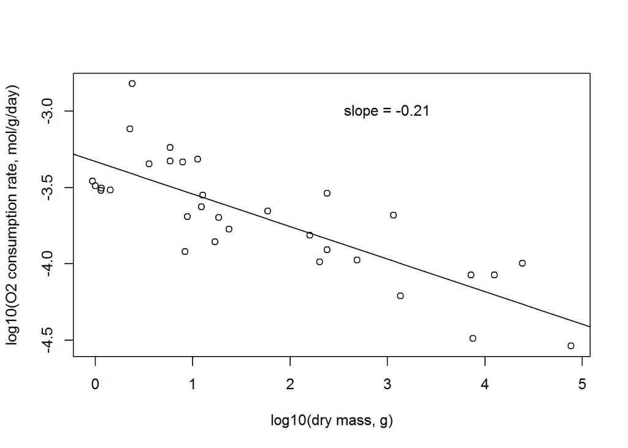

```r
pars.wanted <- c("Wd.i", "VO.i")  # choose parameters of interest

# make an empty matrix to put the values in
all.VOi <- matrix(NA, nrow = length(allDEB.species), ncol = length(pars.wanted))

# loop through all species, get the parameters
for (i in 1:length(allDEB.species)) {
    par.names <- unlist(labels(allStat$allStat[[i]]))
    for (j in 1:length(pars.wanted)) {
        par.slot <- which(par.names == pars.wanted[j])
        all.VOi[i, j] <- unlist(allStat$allStat[[i]][par.slot])
    }
}

# get just the values for a given order
order.slot <- which(par.names == "order")  # find which item contains the taxonomic order
order.wanted <- "Squamata"  # choose order of interest

# loop through all species and find those matching the chosen
# order
all.orders <- vector()
for (i in 1:length(allDEB.species)) {
    all.orders[i] <- unlist(allStat$allStat[[c(i, order.slot)]])
}

# subset the extracted parameters for just those species in
# the chosen order
squam.voi <- all.VOi[which(all.orders %in% order.wanted), ]

plot(log10(squam.voi[, 1]), log10(squam.voi[, 2] * -1), ylab = "log10(O2 consumption rate, mol/g/day)",
    xlab = "log10(dry mass, g)")

# estimate the slope and plot it
estWO2 <- coef(summary(lm(log10(squam.voi[, 2] * -1) ~ log10(squam.voi[,
    1]))))
slp <- estWO2[2]
abline(estWO2[1], estWO2[2])
text(3, -3, paste0("slope = ", round(slp, 2)))
```